# act_report

```python
import pandas as pd
import matplotlib.pyplot as plt
import seaborn as sns
import warnings
warnings.simplefilter(action='ignore')
```

```python
# Load the master dataset
twitter_archive_master= pd.read_csv('twitter_archive_master.csv')
twitter_archive_master
```

|  | tweet_id | timestamp | source_x | text | name | dog_stage | dog_ratings | jpg_url | img_num | prediction_1 | ... | display_text_range | source_y | is_quote_status | retweet_count | favorite_count | favorited | retweeted | possibly_sensitive | possibly_sensitive_appealable | lang |
| --- | --- | --- | --- | --- | --- | --- | --- | --- | --- | --- | --- | --- | --- | --- | --- | --- | --- | --- | --- | --- | --- |
| 0 | 891815181378084864 | 2017-07-31 00:18:03 | http://twitter.com/download/iphone | This is Archie. He is a rare Norwegian Pouncin... | Archie | NaN | 1.2 | https://pbs.twimg.com/media/DGBdLU1WsAANxJ9.jpg | 1 | chihuahua | ... | [0, 121] | <a href="http://twitter.com/download/iphone" r... | False | 3481 | 22055 | False | False | False | False | en |
| 1 | 891689557279858688 | 2017-07-30 15:58:51 | http://twitter.com/download/iphone | This is Darla. She commenced a snooze mid meal... | Darla | NaN | 1.3 | https://pbs.twimg.com/media/DF_q7IAWsAEuuN8.jpg | 1 | paper_towel | ... | [0, 79] | <a href="http://twitter.com/download/iphone" r... | False | 7227 | 36940 | False | False | False | False | en |
| 2 | 891327558926688256 | 2017-07-29 16:00:24 | http://twitter.com/download/iphone | This is Franklin. He would like you to stop ca... | Franklin | NaN | 1.2 | https://pbs.twimg.com/media/DF6hr6BUMAAzZgT.jpg | 2 | basset | ... | [0, 138] | <a href="http://twitter.com/download/iphone" r... | False | 7762 | 35312 | False | False | False | False | en |
| 3 | 891087950875897856 | 2017-07-29 00:08:17 | http://twitter.com/download/iphone | Here we have a majestic great white breaching ... | NaN | NaN | 1.3 | https://pbs.twimg.com/media/DF3HwyEWsAABqE6.jpg | 1 | chesapeake_bay_retriever | ... | [0, 138] | <a href="http://twitter.com/download/iphone" r... | False | 2602 | 17812 | False | False | False | False | en |
| 4 | 890971913173991426 | 2017-07-28 16:27:12 | http://twitter.com/download/iphone | Meet Jax. He enjoys ice cream so much he gets ... | Jax | NaN | 1.3 | https://pbs.twimg.com/media/DF1eOmZXUAALUcq.jpg | 1 | appenzeller | ... | [0, 140] | <a href="http://twitter.com/download/iphone" r... | False | 1664 | 10364 | False | False | False | False | en |
| ... | ... | ... | ... | ... | ... | ... | ... | ... | ... | ... | ... | ... | ... | ... | ... | ... | ... | ... | ... | ... | ... |
| 1979 | 666049248165822465 | 2015-11-16 00:24:50 | http://twitter.com/download/iphone | Here we have a 1949 1st generation vulpix. Enj... | NaN | NaN | 0.5 | https://pbs.twimg.com/media/CT5IQmsXIAAKY4A.jpg | 1 | miniature_pinscher | ... | [0, 120] | <a href="http://twitter.com/download/iphone" r... | False | 37 | 89 | False | False | False | False | en |
| 1980 | 666044226329800704 | 2015-11-16 00:04:52 | http://twitter.com/download/iphone | This is a purebred Piers Morgan. Loves to Netf... | a | NaN | 0.6 | https://pbs.twimg.com/media/CT5Dr8HUEAA-lEu.jpg | 1 | rhodesian_ridgeback | ... | [0, 137] | <a href="http://twitter.com/download/iphone" r... | False | 115 | 247 | False | False | False | False | en |
| 1981 | 666033412701032449 | 2015-11-15 23:21:54 | http://twitter.com/download/iphone | Here is a very happy pup. Big fan of well-main... | a | NaN | 0.9 | https://pbs.twimg.com/media/CT4521TWwAEvMyu.jpg | 1 | german_shepherd | ... | [0, 130] | <a href="http://twitter.com/download/iphone" r... | False | 36 | 100 | False | False | False | False | en |
| 1982 | 666029285002620928 | 2015-11-15 23:05:30 | http://twitter.com/download/iphone | This is a western brown Mitsubishi terrier. Up... | a | NaN | 0.7 | https://pbs.twimg.com/media/CT42GRgUYAA5iDo.jpg | 1 | redbone | ... | [0, 139] | <a href="http://twitter.com/download/iphone" r... | False | 39 | 112 | False | False | False | False | en |
| 1983 | 666020888022790149 | 2015-11-15 22:32:08 | http://twitter.com/download/iphone | Here we have a Japanese Irish Setter. Lost eye... | NaN | NaN | 0.8 | https://pbs.twimg.com/media/CT4udn0WwAA0aMy.jpg | 1 | welsh_springer_spaniel | ... | [0, 131] | <a href="http://twitter.com/download/iphone" r... | False | 423 | 2292 | False | False | False | False | en |

1984 rows × 32 columns

# Analysing the Data

Once I completed the wrangling the data, I stored the data as a `.csv` file named`twitter_archive_master.csv`.

For analysis the clean master CSV file was assigned to the variable name twitter_master_archive. From the clean dataframe, there were a lot of insights and possibilities to explore. I was curious to know more about the different dog stages, the dog breeds, dog names, and the releationship between favourite count and retweet count.

To get make satisfy my curiosity, I created a list of questions listed below

> 1. What is the favorite dog_stage?
> 2. What is the dog breed has the best ratings?
> 3. What are the most common dog name?
> 4. What kind of relationship exists between favorite count and retweet count?

## Insights

### Favorite dog stage

To know the favorite dog stage, I created a new dataframe from the twitter_master_archive dataframe by grouping on the dog stage column and then summing the favourite count of each individual group.

To format it with the most at the top, I used the `sort_values()` method.

From my exploration, I discovered the Pupper dog stage was the most favorite with a count of 1259797.

```python
# 1: Favorite count
# Group by dog_stage and sum the favorite_count

dog_stage_fav=twitter_archive_master.groupby('dog_stage').sum()[['favorite_count']]\
.reset_index().sort_values('favorite_count', ascending=False)
dog_stage_fav
```

|  | dog_stage | favorite_count |
| --- | --- | --- |
| 5 | pupper | 1259797 |
| 0 | doggo | 1091473 |
| 6 | puppo | 430661 |
| 2 | doggopupper | 108357 |
| 4 | floofer | 78582 |
| 3 | doggopuppo | 41919 |
| 1 | doggofloofer | 14846 |

### Favorite dog breed

To know the favorite dog breed, I first created a new column holding the breed of the best prediction and called it dog breed.

I then created a new dataframe from the twitter_master_archive dataframe by grouping on the dog_breed column and then summing the favourite count of each individual group.

To format it with the most at the top, I used the `sort_values()` method.

From my exploration, I discovered the Golden Retrievers were favorite with a count of 1688502.

```python
# to create single column of best predictions breed

twitter_archive_master['dog_breed']= 'None'

for i in range(len(twitter_archive_master)):
    if twitter_archive_master['is_prediction_1_dog?'][i]== True:
        twitter_archive_master['dog_breed'][i]= twitter_archive_master['prediction_1'][i]
    elif twitter_archive_master['is_prediction_2_dog?'][i]== True:
        twitter_archive_master['dog_breed'][i]= twitter_archive_master['prediction_2'][i]
    elif twitter_archive_master['is_prediction_3_dog?'][i]== True:
        twitter_archive_master['dog_breed'][i]= twitter_archive_master['prediction_3'][i]
    else:
        twitter_archive_master['dog_breed'][i]= 'None'

dog_breed_fav= twitter_archive_master.groupby('dog_breed').sum()[['favorite_count']]\
.reset_index().sort_values('favorite_count', ascending=False)
dog_breed_fav[:20]
```

|  | dog_breed | favorite_count |
| --- | --- | --- |
| 0 | None | 1855044 |
| 46 | golden_retriever | 1688502 |
| 63 | labrador_retriever | 1039755 |
| 81 | pembroke | 905941 |
| 28 | chihuahua | 640138 |
| 42 | french_bulldog | 526239 |
| 89 | samoyed | 482188 |
| 29 | chow | 389611 |
| 31 | cocker_spaniel | 352270 |
| 83 | pug | 325451 |
| 67 | malamute | 304761 |
| 104 | toy_poodle | 276424 |
| 82 | pomeranian | 276200 |
| 27 | chesapeake_bay_retriever | 265981 |
| 40 | eskimo_dog | 243439 |
| 26 | cardigan | 229714 |
| 64 | lakeland_terrier | 191301 |
| 43 | german_shepherd | 185224 |
| 71 | miniature_pinscher | 172471 |
| 7 | basset | 171452 |

### Most common dog names

To get the most common dog names, I used the `.value_counts()` method which returns the counts of unique values of the column.

The result by default is in descending order so that the first element is the most frequently-occurring element.

Based on the findings the most common dog names in the #weratedogs archive are `Oliver, Cooper, Charlie, Penny, Tucker, Lucy, Sadie and Winston`.

```python
# converting to lowercase to ensure names are no divided by string case
twitter_archive_master['name']= twitter_archive_master['name'].str.lower()
name_df= twitter_archive_master.groupby('name').count()[['tweet_id']]\
.reset_index().sort_values('tweet_id', ascending=False)
name_df.head(20)
```

|  | name | tweet_id |
| --- | --- | --- |
| 0 | a | 55 |
| 207 | cooper | 10 |
| 169 | charlie | 10 |
| 637 | oliver | 10 |
| 543 | lucy | 9 |
| 663 | penny | 9 |
| 884 | tucker | 9 |
| 749 | sadie | 8 |
| 918 | winston | 8 |
| 224 | daisy | 7 |
| 853 | the | 7 |
| 531 | lola | 7 |
| 868 | toby | 7 |
| 100 | bo | 6 |
| 810 | stanley | 6 |
| 70 | bella | 6 |
| 486 | koda | 6 |
| 412 | jax | 6 |
| 25 | an | 6 |
| 539 | louis | 5 |

### Relationship between favorite count and retweet count

I created a heat map and a regression-scatterplot to assess the relationship between retweet count and favorite count.

I disconvered that there is a stong positeve correlation between the two variables

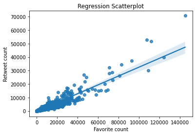

```python
sns.regplot('favorite_count', 'retweet_count', data= twitter_archive_master)
plt.title('Regression Scatterplot')
plt.xlabel('Favorite count')
plt.ylabel('Retweet count')
plt.show()
```

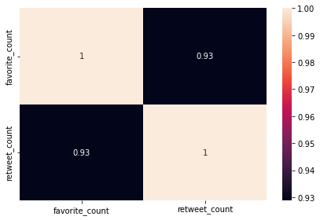

```python
sns.heatmap(twitter_archive_master[['favorite_count', 'retweet_count']].corr(), annot=True)
plt.tight_layout()
```

### Top 20 Best rated breeds

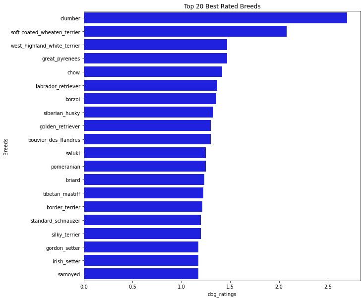

```python
breed_ratings= twitter_archive_master.groupby('dog_breed').mean()[['dog_ratings']]\
.reset_index().sort_values('dog_ratings', ascending=False)

fig, axes= plt.subplots(figsize=(10,10))
sns.barplot(y='dog_breed', x='dog_ratings', data=breed_ratings[breed_ratings['dog_breed']!= 'None'][:20], color='blue')
plt.title('Top 20 Best Rated Breeds')
plt.ylabel('Breeds')
plt.show()
```